# Reproduction of results

### Results

The results for ResNMTF applied on the various real datasets are obtained from the investigations above, producing the following results:

- Table 2, main F-score results
- Figure 5A, relevance against increasing $\omega$ at “RealData/3sources/stab_plot_ResNMTF_F.pdf”

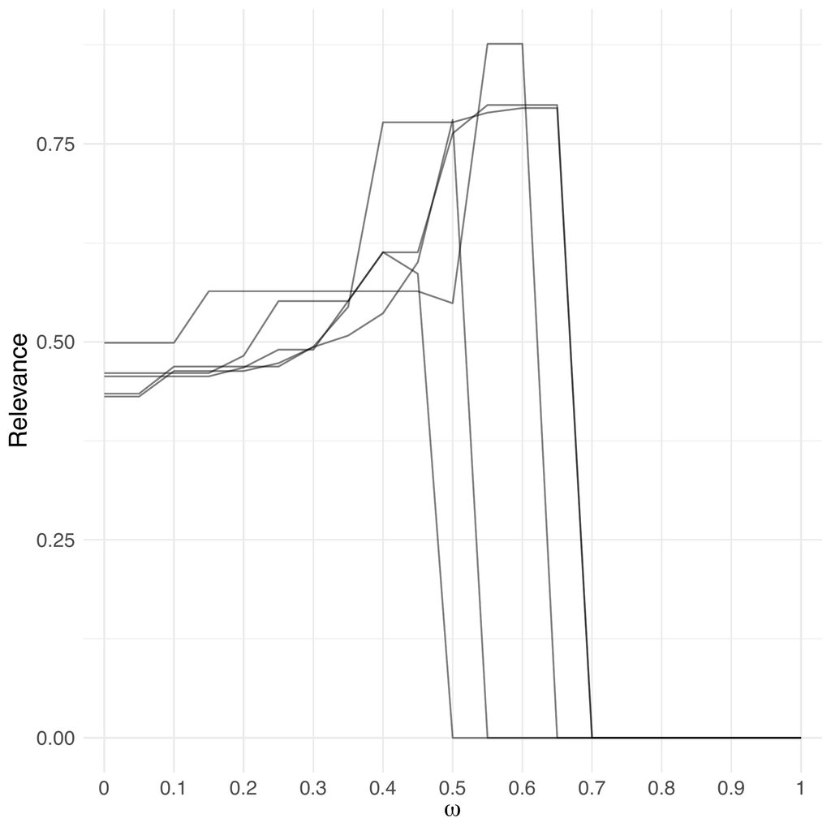

  Figure 5A

- Figure 5B, illustrating correlation of F score and the bisilhouette score at “RealData/single_cell/f_score_bis_sil.pdf”

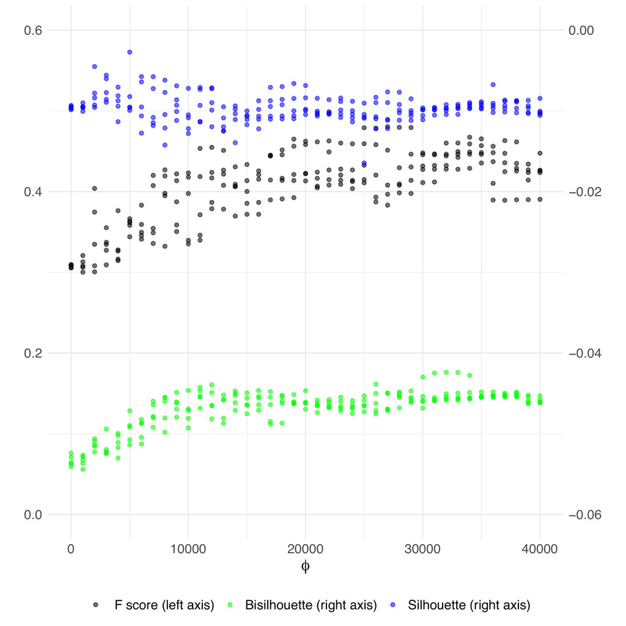

  Figure 5B

- Figure 6B, the bisilhouette plot for the 3sources dataset at “RealData/3sources/data/stability_ResNMTF_F/bisil_plot.pdf”

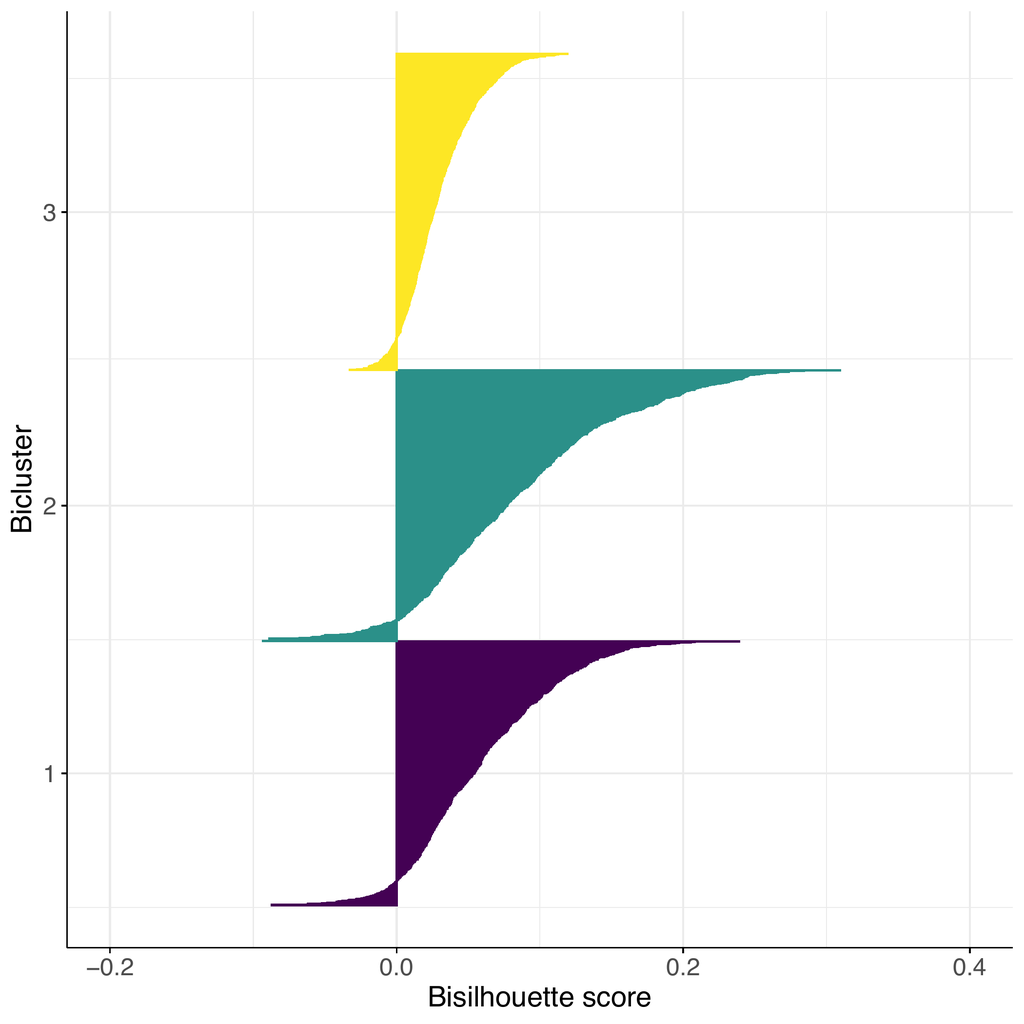

  Figure 6B

- Table S1, the distance study at “RealData/all_results.csv”
- Table S2, the bisilhouette scores of the analysis

Lastly, Figure 6A is produced via the following code chunk which creates and save the bisilhouette plot for the shuffled synthetic data. This is saved to `Exploration/visual_data/shuffled_bisil_plot.pdf`.

```r
source("Exploration/visualisation_ex.r")
```

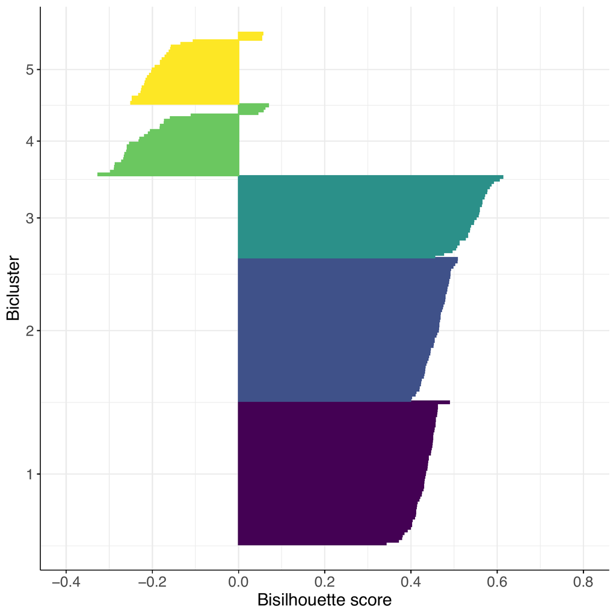

## Supplementary material figures

### Figure S1

The following code chunk creates and saves the two subfigures in the supplementary material.

```r
source("Exploration/visualisation_ex.r")
```

These are saved to `Exploration/convergence_data/error_plot.pdf` and `RealData/3cancers/data/stability/error_plot.pdf`.

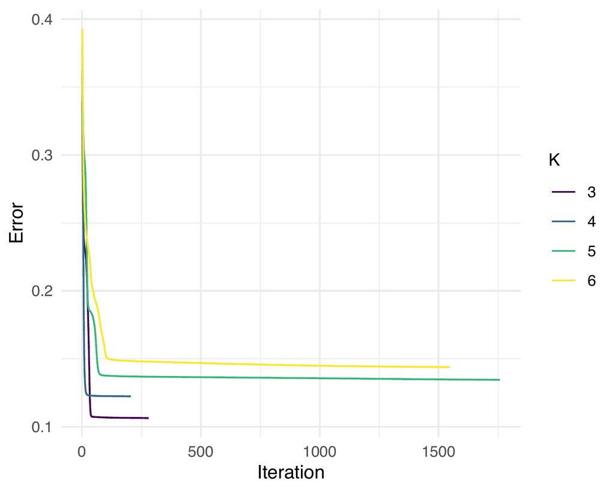

Figure S1A

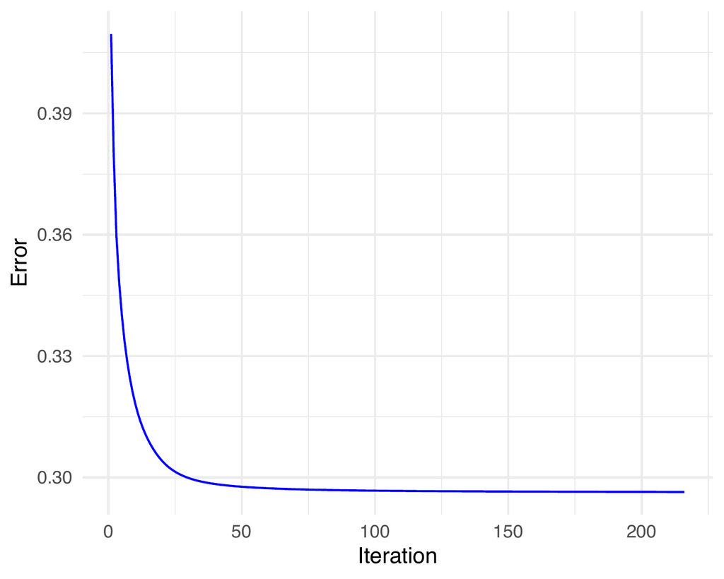

Figure S1B

### Figure S2

The following code chunk creates and save the two subfigures in the supplementary materail.

```r
source("Exploration/JSD_diff_dists.r")
```

These are saved to `Exploration/f_data_dists.pdf` and `Exploration/shuffled_data_dists.pdf`.

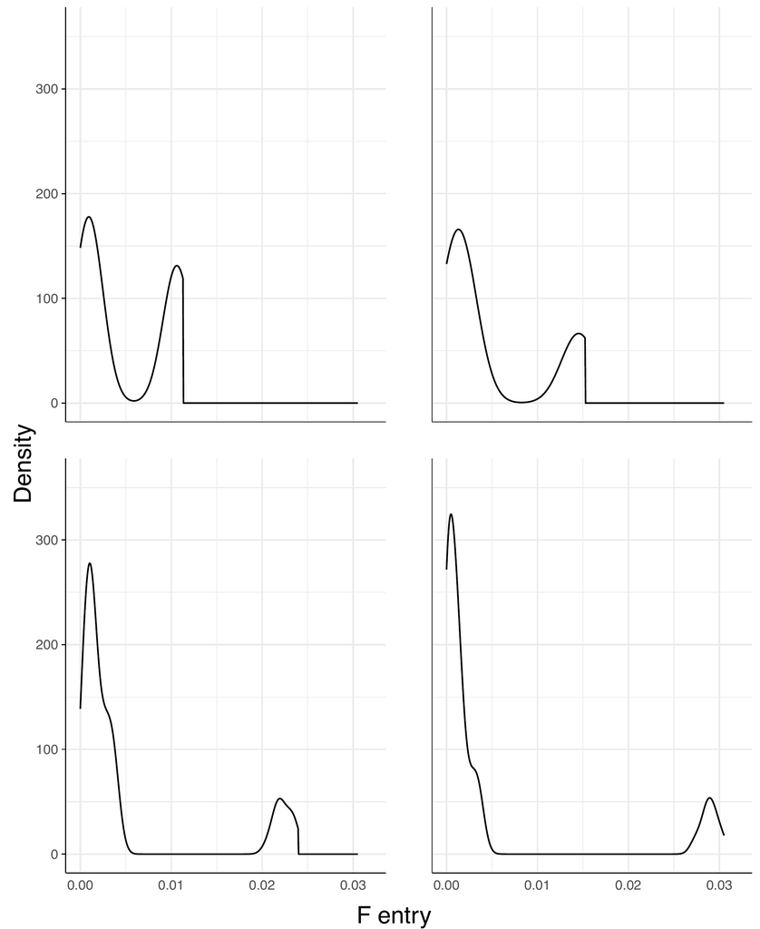

Figure S2A

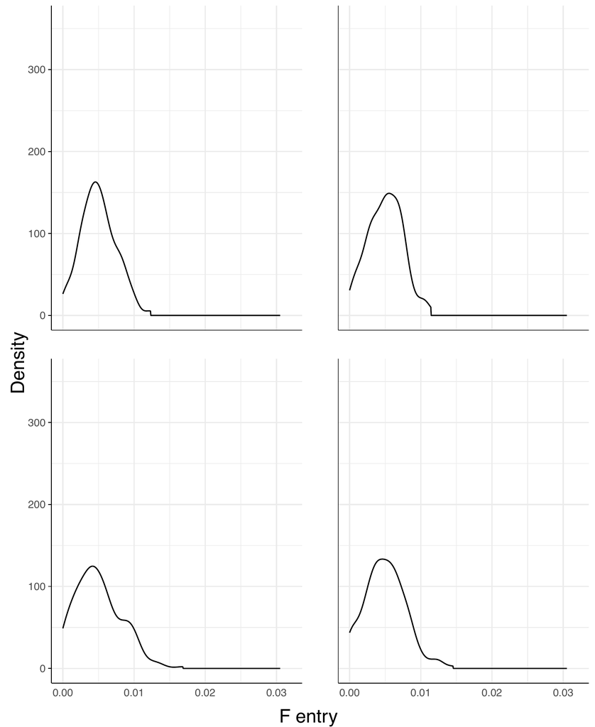

Figure S2B